# ClusterMaster - Dokumentacja Techniczna

## 1. Wstęp

### 1.1 Czym jest ClusterMaster?

**ClusterMaster** to kompleksowa platforma webowa do zarządzania klastrami Kubernetes, która umożliwia:

- **Tworzenie klastrów** jednym kliknięciem - zarówno lokalnych (do testów i developmentu) jak i produkcyjnych w chmurze AWS
- **Monitoring** w czasie rzeczywistym - wbudowana integracja z Prometheus i Grafana
- **Backup i restore** - zabezpieczenie konfiguracji klastrów
- **Instalacja aplikacji** - wyszukiwanie i instalacja aplikacji z Helm charts
- **Skalowanie** - dynamiczne dodawanie i usuwanie węzłów

### 1.2 Dla kogo jest ClusterMaster?

| Rola | Korzyści |
| --- | --- |
| **DevOps Engineer** | Szybkie tworzenie środowisk testowych, automatyzacja deploymentów |
| **Developer** | Lokalne klastry K8s do testowania aplikacji bez znajomości szczegółów infrastruktury |
| **Team Lead** | Przegląd stanu wszystkich klastrów w jednym miejscu |
| **Student/Learner** | Nauka Kubernetes bez skomplikowanej konfiguracji |

### 1.3 Główne funkcjonalności

```
┌─────────────────────────────────────────────────────────────────┐
│                      ClusterMaster                               │
├─────────────────┬─────────────────┬─────────────────────────────┤
│  Klastry        │  Monitoring     │  Zarządzanie                │
│  Lokalne        │                 │                             │
├─────────────────┼─────────────────┼─────────────────────────────┤
│ • k3d           │ • Prometheus    │ • Backup/Restore            │
│ • Kind          │ • Grafana       │ • Helm Apps                 │
│ • AWS EKS       │ • CloudWatch    │ • Skalowanie                │
│                 │ • Metrics Server│ • Activity Log              │
└─────────────────┴─────────────────┴─────────────────────────────┘
```

### 1.4 Architektura systemu

```
┌──────────────────┐     HTTP/REST      ┌──────────────────┐
│                  │ ◄────────────────► │                  │
│    Frontend      │                    │     Backend      │
│    (Vue.js)      │     SSE Events     │    (FastAPI)     │
│    Port: 5173    │ ◄──────────────    │    Port: 8000    │
│                  │                    │                  │
└────────┬─────────┘                    └────────┬─────────┘
         │                                       │
         │ Firebase Auth                         │ kubectl/helm/terraform
         ▼                                       ▼
┌──────────────────┐                    ┌──────────────────┐
│                  │                    │                  │
│    Firebase      │                    │   Kubernetes     │
│  (Auth + DB)     │                    │   Clusters       │
│                  │                    │                  │
└──────────────────┘                    └──────────────────┘
```

## 2. Przewodnik Użytkownika

### 2.1 Pierwsze kroki po uruchomieniu

#### Krok 1: Rejestracja i logowanie

1. Otwórz aplikację w przeglądarce: `http://localhost:5173`
2. Kliknij **“Zarejestruj się”** jeśli nie masz konta
3. Podaj email i hasło (min. 6 znaków)
4. Po rejestracji zaloguj się swoimi danymi

> **Wskazówka:** Twoje dane logowania są bezpiecznie przechowywane w Firebase Authentication.

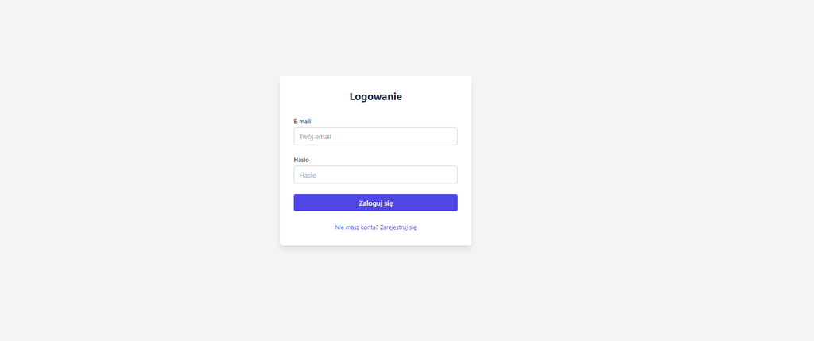

Screenshot 1: Strona logowania

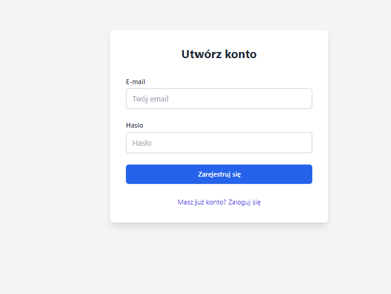

Screenshot 2: Strona rejestracji

#### Krok 2: Panel główny (Dashboard)

Po zalogowaniu zobaczysz panel główny zawierający:

| Sekcja | Opis |
| --- | --- |
| **Statystyki** | Liczba aktywnych klastrów, węzłów, zadań w toku |
| **Klastry lokalne** | Lista klastrów k3d/Kind z możliwością zarządzania |
| **Klastry AWS EKS** | Lista klastrów chmurowych (wymaga credentials AWS) |
| **Historia operacji** | Ostatnie wykonane akcje z ich statusem |

[figure not shown]

Screenshot 3: Panel główny (Dashboard) - widok ogólny

[figure not shown]

### 2.2 Tworzenie klastra lokalnego

Klastry lokalne są idealne do: - Testowania aplikacji przed deploymentem - Nauki Kubernetes - Developmentu lokalnego - CI/CD pipelines

#### Krok po kroku:

1. **Przejdź do “Deploy”** w menu nawigacyjnym
2. **Wybierz typ klastra:**
   - **k3d** (zalecany) - lżejszy, szybszy start
   - **Kind** - pełniejsza emulacja Kubernetes
3. **Wypełnij formularz:**

   | Pole | Opis | Przykład |
   | --- | --- | --- |
   | Nazwa klastra | Unikalna nazwa (bez spacji) | `my-test-cluster` |
   | Liczba węzłów | Ilość worker nodes | `2` |
   | Wersja K8s | Opcjonalne | `1.28.0` |

4. **Kliknij “Utwórz klaster”**
5. **Poczekaj** - tworzenie trwa 1-3 minuty

> **Uwaga:** Docker Desktop musi być uruchomiony!

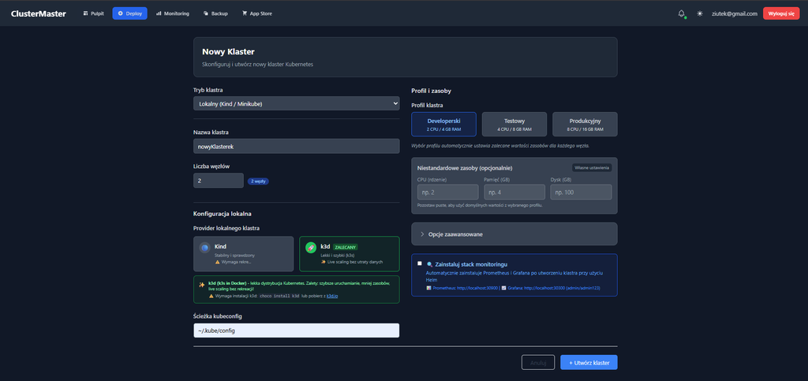

Screenshot 5: Formularz tworzenia klastra lokalnego

[figure not shown]

Screenshot 6: Tworzenie klastra w toku (loading state)

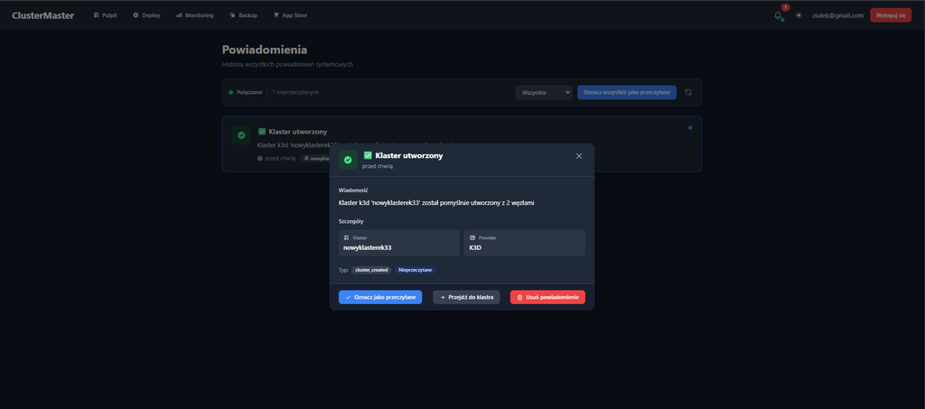

Screenshot 7: Sukces utworzenia klastra

#### Co się dzieje w tle?

```
1. Backend tworzy klaster przez k3d/kind CLI
2. Konfiguruje kubectl context
3. Przydziela porty dla monitoringu
4. Aktualizuje listę klastrów
5. Wysyła powiadomienie o sukcesie
```

### 2.3 Tworzenie klastra AWS EKS

Klastry EKS są przeznaczone do: - Środowisk produkcyjnych - Aplikacji wymagających wysokiej dostępności - Integracji z innymi usługami AWS

#### Wymagania wstępne:

- Konto AWS z odpowiednimi uprawnieniami
- AWS Access Key ID i Secret Access Key
- Terraform zainstalowany lokalnie

#### Krok po kroku:

1. **Przejdź do “Deploy”** → zakładka **“AWS EKS”**
2. **Wprowadź dane AWS:**

   | Pole | Opis |
   | --- | --- |
   | AWS Access Key | Twój klucz dostępu |
   | AWS Secret Key | Tajny klucz (nie jest zapisywany na serwerze!) |
   | Region | np. `eu-central-1` (Frankfurt) |

3. **Skonfiguruj klaster:**

   | Pole | Opis | Zalecane |
   | --- | --- | --- |
   | Nazwa | Unikalna nazwa | `prod-cluster` |
   | Liczba węzłów | Worker nodes | `2-3` |
   | Typ instancji | EC2 instance type | `t3.medium` |
   | Min/Max nodes | Auto-scaling | `1 / 5` |

4. **Kliknij “Utwórz klaster EKS”**
5. **Poczekaj** - tworzenie EKS trwa **15-25 minut**

> **Koszty:** EKS to usługa płatna! Sprawdź cennik AWS przed utworzeniem.

[figure not shown]

Screenshot 8: Formularz tworzenia klastra AWS EKS

### 2.4 Instalacja monitoringu

Monitoring pozwala śledzić: - Zużycie CPU i pamięci węzłów - Stan podów i deploymentów - Metryki aplikacji - Alerty i powiadomienia

#### Jak zainstalować:

1. **Na stronie głównej** znajdź swój klaster
2. **Kliknij ikonę wykresu** lub przejdź do **“Monitoring”**
3. **Wybierz klaster** z listy
4. **Kliknij “Zainstaluj monitoring”**
5. **Poczekaj** - instalacja trwa 2-5 minut

#### Co zostanie zainstalowane:

| Komponent | Opis | Domyślny port |
| --- | --- | --- |
| **Prometheus** | Zbieranie metryk | `30090-30199` |
| **Grafana** | Wizualizacja | `30030-30089` |
| **Metrics Server** | Metryki K8s | - |

#### Dostęp do dashboardów:

Po instalacji kliknij **“Otwórz Grafana”** lub **“Otwórz Prometheus”** aby otworzyć dashboard w przeglądarce.

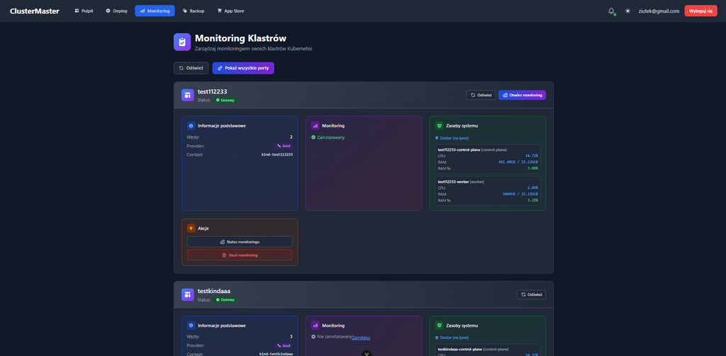

Screenshot 9: Strona Monitoring - wybór klastra

[figure not shown]

Screenshot 10: Panel monitoringu dla klastra

[figure not shown]

Screenshot 11: Dashboard Grafana (zewnętrzne okno)

### 2.5 Tworzenie backupów

Backupy chronią przed: - Przypadkowym usunięciem konfiguracji - Błędami podczas aktualizacji - Utratą danych przy awarii

#### Tworzenie backupu:

1. **Przejdź do “Backup”** w menu
2. **Wybierz klaster** do backupu
3. **Opcjonalnie** podaj własną nazwę backupu
4. **Kliknij “Utwórz backup”**

#### Co zawiera backup:

```
backup_mycluster_20260110_120000.zip
├── manifests/
│   ├── deployments.yaml
│   ├── services.yaml
│   ├── configmaps.yaml
│   ├── secrets.yaml (zaszyfrowane)
│   └── ...
├── cluster_info.json
└── metadata.json
```

#### Przywracanie z backupu:

1. **Na liście backupów** znajdź żądany backup
2. **Kliknij “Przywróć”**
3. **Opcjonalnie** podaj nową nazwę klastra
4. **Potwierdź** operację

> **Uwaga:** Przywracanie tworzy nowy klaster, nie nadpisuje istniejącego!

[figure not shown]

Screenshot 12: Strona Backup - widok główny

[figure not shown]

Screenshot 13: Modal szczegółów backupu

### 2.6 Instalacja aplikacji (Helm Charts)

ClusterMaster pozwala łatwo instalować popularne aplikacje:

#### Dostępne kategorie aplikacji:

| Kategoria | Przykłady |
| --- | --- |
| **Bazy danych** | PostgreSQL, MySQL, MongoDB, Redis |
| **Message Queues** | RabbitMQ, Kafka |
| **CI/CD** | Jenkins, ArgoCD, GitLab Runner |
| **Monitoring** | Prometheus, Grafana, ELK Stack |
| **Web Servers** | Nginx, Apache, Traefik |

#### Instalacja aplikacji:

1. **Przejdź do “Apps”** w menu
2. **Wybierz klaster** docelowy
3. **Wyszukaj aplikację** (np. “postgresql”)
4. **Kliknij “Zainstaluj”** przy wybranym chart
5. **Skonfiguruj wartości** (opcjonalne)
6. **Potwierdź instalację**

#### Przykład: Instalacja PostgreSQL

```
Nazwa release: my-postgres
Namespace: default
Helm Chart: bitnami/postgresql

Values (opcjonalne):
{
  "auth": {
    "postgresPassword": "mySecretPassword"
  },
  "primary": {
    "persistence": {
      "size": "10Gi"
    }
  }
}
```

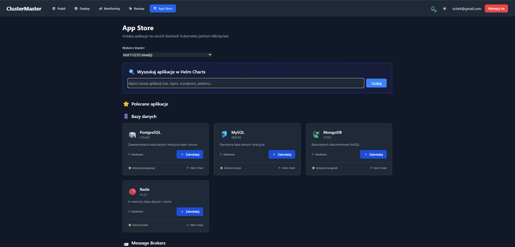

Screenshot 14: Widok sekcji “Apps” z listą dostępnych aplikacji

[figure not shown]

[figure not shown]

Screenshot 16: Lista zainstalowanych aplikacji z akcjami

### 2.7 Skalowanie klastra

Skalowanie pozwala dostosować zasoby do aktualnych potrzeb.

#### Kiedy skalować?

| Sytuacja | Akcja |
| --- | --- |
| Wysokie CPU/RAM | Dodaj węzły |
| Niski ruch | Usuń węzły |
| Nowe środowisko | Dodaj węzły testowe |
| Oszczędność kosztów | Zmniejsz do minimum |

#### Różnice między providerami:

| Provider | Skalowanie | Czas | Uwagi |
| --- | --- | --- | --- |
| **k3d** | Natychmiastowe | ~30s | Dodaje/usuwa kontenery |
| **Kind** | Wymaga recreate | 2-3min | Tworzy klaster od nowa |
| **EKS** | Auto-scaling | 3-5min | AWS zarządza nodes |

[figure not shown]

Screenshot 17: Widok sekcji “Scale” z opcjami skalowania

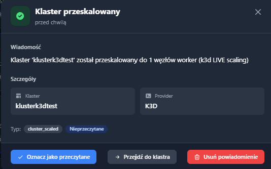

### 2.8 Historia operacji i powiadomienia

#### Activity Log

Panel **“Historia operacji”** na stronie głównej pokazuje:

| Pole | Opis |
| --- | --- |
| **Status** | success / error / in-progress |
| **Czas** | Kiedy operacja została wykonana |
| **Typ** | cluster_create, backup_create, itp. |
| **Szczegóły** | Dodatkowe informacje |

**Kliknij na wpis** aby zobaczyć szczegóły operacji.

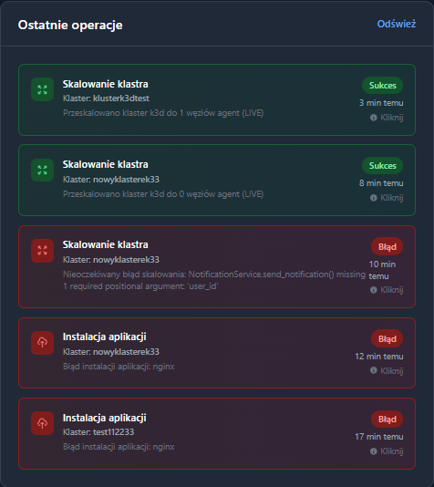

Screenshot 19: Panel “Historia operacji” na stronie głównej

#### Powiadomienia real-time

Ikona dzwonka w prawym górnym rogu pokazuje: - Powiadomienia o zakończonych operacjach - Błędy wymagające uwagi - Informacje systemowe

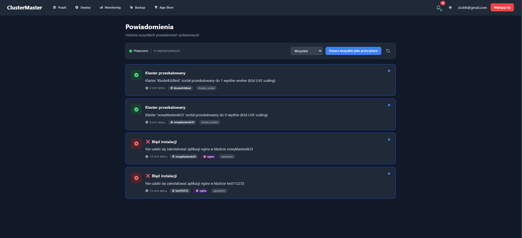

Screenshot 20: Rozwinięte powiadomienia po kliknięciu dzwonka

### 2.9 Zarządzanie klastrem

#### Dostępne akcje dla klastra:

| Akcja | Ikona | Opis |
| --- | --- | --- |
| **Status** | i | Szczegółowe informacje o klastrze |
| **Monitoring** | wykres | Instalacja/dostęp do monitoringu |
| **Stop** | pauza | Zatrzymanie klastra (zachowuje dane) |
| **Start** | play | Uruchomienie zatrzymanego klastra |
| **Restart** | reload | Restart wszystkich węzłów |
| **Usuń** | kosz | Permanentne usunięcie klastra |

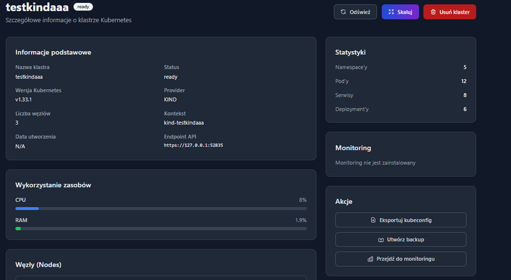

#### Szczegóły klastra:

Kliknij na nazwę klastra aby zobaczyć:

```
┌─────────────────────────────────────────────────────┐
│ Klaster: my-test-cluster                            │
├─────────────────────────────────────────────────────┤
│ Provider:        k3d                                │
│ Status:          Running                            │
│ Węzły:           3 (1 control-plane, 2 workers)     │
│ Wersja K8s:      v1.28.0                           │
│ Context:         k3d-my-test-cluster               │
│ CPU:             23% średnio                        │
│ RAM:             45% średnio                        │
├─────────────────────────────────────────────────────┤
│ Węzły:                                              │
│ ├─ my-test-cluster-server-0    Ready  control-plane│
│ ├─ my-test-cluster-agent-0     Ready  worker       │
│ └─ my-test-cluster-agent-1     Ready  worker       │
└─────────────────────────────────────────────────────┘
```

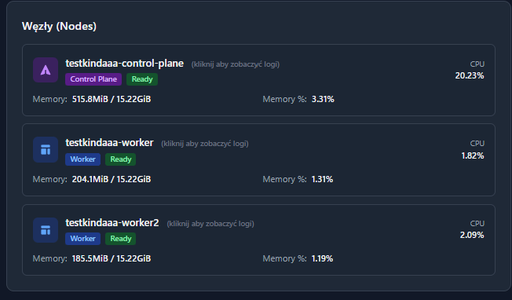

Screenshot 22: Widok szczegółów klastra (Cluster Details)

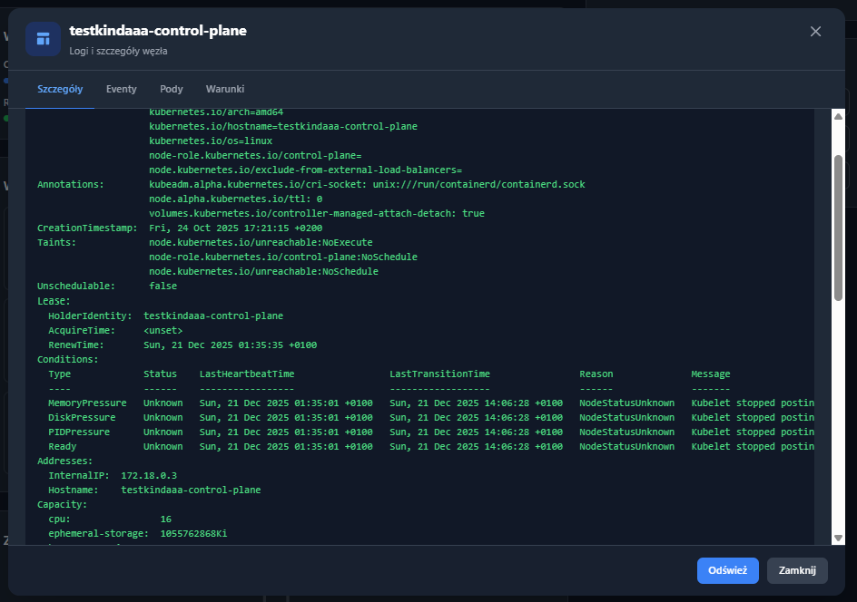

Screenshot 23: Logi węzła klastra (Node Logs Modal)

## 3. Dokumentacja API

### 3.1 Rodzaj API

**Typ:** REST API  
**Format danych:** JSON  
**Base URL:** `http://localhost:8000/api/v1`  
**Protokół:** HTTP/HTTPS  
**Notyfikacje:** Server-Sent Events (SSE) dla powiadomień w czasie rzeczywistym

### 3.2 Endpointy API

#### 3.2.1 Health Check

| Endpoint | Metoda | Opis |
| --- | --- | --- |
| `/api/v1/health` | GET | Sprawdzenie stanu serwisu |

**Parametry:** Brak

**Odpowiedź:**

```json
{
  "status": "healthy",
  "service": "ClusterMaster API"
}
```

#### 3.2.2 Zarządzanie Klastrami Lokalnymi

| Endpoint | Metoda | Opis |
| --- | --- | --- |
| `/api/v1/local-cluster` | GET | Lista wszystkich klastrów z detalami |
| `/api/v1/local-cluster/list` | GET | Lista nazw klastrów |
| `/api/v1/local-cluster/create` | POST | Tworzenie nowego klastra |
| `/api/v1/local-cluster/{cluster_name}` | DELETE | Usunięcie klastra |
| `/api/v1/local-cluster/{cluster_name}/status` | GET | Status klastra |
| `/api/v1/local-cluster/{cluster_name}/config` | GET | Konfiguracja klastra |
| `/api/v1/local-cluster/{cluster_name}/resources` | GET | Zasoby klastra |
| `/api/v1/local-cluster/{cluster_name}/profile` | GET | Profil klastra |
| `/api/v1/local-cluster/{cluster_name}/kubeconfig` | GET | Pobranie kubeconfig |
| `/api/v1/local-cluster/{cluster_name}/nodes/{node_name}/logs` | GET | Logi węzła |
| `/api/v1/local-cluster/{cluster_name}/stop` | POST | Zatrzymanie klastra |
| `/api/v1/local-cluster/{cluster_name}/start` | POST | Uruchomienie klastra |
| `/api/v1/local-cluster/{cluster_name}/restart` | POST | Restart klastra |
| `/api/v1/local-cluster/create-with-monitoring` | POST | Tworzenie klastra z monitoringiem |

**POST `/api/v1/local-cluster/create` - Parametry:**

```json
{
  "cluster_name": "string",      // Wymagane - nazwa klastra
  "node_count": "integer",       // Wymagane - liczba węzłów
  "k8s_version": "string"        // Opcjonalne - wersja Kubernetes
}
```

**Odpowiedź sukcesu:**

```json
{
  "cluster_name": "my-cluster",
  "status": "success",
  "message": "Klaster utworzony pomyślnie",
  "provider": "k3d"
}
```

**GET `/api/v1/local-cluster` - Parametry Query:** - `include_resources` (boolean) - czy dołączyć informacje o zasobach

**Odpowiedź:**

```json
{
  "clusters": [
    {
      "name": "my-cluster",
      "status": "running",
      "provider": "k3d",
      "node_count": 3,
      "context": "k3d-my-cluster",
      "kubernetes_version": "1.28.0",
      "resources": {
        "node_count": 3,
        "cpu_usage": 25,
        "memory_usage": 45,
        "nodes": [...]
      }
    }
  ]
}
```

#### 3.2.3 Zarządzanie Klastrami AWS EKS

| Endpoint | Metoda | Opis |
| --- | --- | --- |
| `/api/v1/eks-cluster/create` | POST | Tworzenie klastra EKS |
| `/api/v1/eks-cluster/list` | POST | Lista klastrów EKS |
| `/api/v1/eks-cluster/{cluster_name}/details` | POST | Szczegóły klastra EKS |
| `/api/v1/eks-cluster/{cluster_name}` | DELETE | Usunięcie klastra EKS |
| `/api/v1/eks-cluster/{cluster_name}/scale` | POST | Skalowanie klastra EKS |
| `/api/v1/eks-cluster/{cluster_name}/install-metrics` | POST | Instalacja Metrics Server |

**POST `/api/v1/eks-cluster/create` - Parametry:**

```json
{
  "cluster_name": "string",       // Wymagane - nazwa klastra
  "region": "string",             // Wymagane - region AWS (np. "eu-central-1")
  "aws_access_key": "string",     // Wymagane - AWS Access Key ID
  "aws_secret_key": "string",     // Wymagane - AWS Secret Access Key
  "node_count": "integer",        // Opcjonalne - liczba węzłów (default: 2)
  "instance_type": "string",      // Opcjonalne - typ instancji (default: "t3.medium")
  "vpc_cidr": "string",           // Opcjonalne - CIDR VPC (default: "10.0.0.0/16")
  "disk_size": "integer",         // Opcjonalne - rozmiar dysku GB (default: 20)
  "min_nodes": "integer",         // Opcjonalne - min nodes auto-scaling (default: 1)
  "max_nodes": "integer",         // Opcjonalne - max nodes auto-scaling (default: 3)
  "k8s_version": "string"         // Opcjonalne - wersja K8s (default: "1.30")
}
```

#### 3.2.4 Monitoring

| Endpoint | Metoda | Opis |
| --- | --- | --- |
| `/api/v1/monitoring/install/{cluster_name}` | POST | Instalacja Prometheus + Grafana |
| `/api/v1/monitoring/uninstall/{cluster_name}` | DELETE | Deinstalacja monitoringu |
| `/api/v1/monitoring/status/{cluster_name}` | GET | Status monitoringu |
| `/api/v1/monitoring/ports` | GET | Wszystkie porty monitoringu |
| `/api/v1/monitoring/ports/{cluster_name}` | GET | Porty dla klastra |
| `/api/v1/monitoring/port-forward/start/{cluster_name}` | POST | Start port-forward |
| `/api/v1/monitoring/port-forward/stop/{cluster_name}` | POST | Stop port-forward |
| `/api/v1/monitoring/install-metrics-server/{cluster_name}` | POST | Instalacja Metrics Server |
| `/api/v1/monitoring/cloudwatch-metrics/{cluster_name}` | GET | Metryki CloudWatch (EKS) |

**Odpowiedź `/api/v1/monitoring/status/{cluster_name}`:**

```json
{
  "success": true,
  "cluster_name": "my-cluster",
  "monitoring_installed": true,
  "prometheus": {
    "status": "running",
    "port": 30100
  },
  "grafana": {
    "status": "running",
    "port": 30040
  }
}
```

#### 3.2.5 Backup i Restore

| Endpoint | Metoda | Opis |
| --- | --- | --- |
| `/api/v1/backup/info` | GET | Informacje o katalogu backupów |
| `/api/v1/backup/list` | GET | Lista wszystkich backupów |
| `/api/v1/backup/create/{cluster_name}` | POST | Tworzenie backupu |
| `/api/v1/backup/details/{backup_name}` | GET | Szczegóły backupu |
| `/api/v1/backup/delete/{backup_name}` | DELETE | Usunięcie backupu |
| `/api/v1/backup/restore/{backup_name}` | POST | Przywrócenie z backupu |
| `/api/v1/backup/download/{backup_name}` | GET | Pobranie pliku backupu |
| `/api/v1/backup/change-directory` | POST | Zmiana katalogu backupów |

**POST `/api/v1/backup/create/{cluster_name}` - Parametry Query:** - `backup_name` (string, opcjonalne) - niestandardowa nazwa backupu

**Odpowiedź:**

```json
{
  "success": true,
  "backup_name": "my-cluster_backup_20260110_120000",
  "message": "Backup utworzony pomyślnie"
}
```

**Struktura BackupInfo:**

```json
{
  "backup_name": "string",
  "cluster_name": "string",
  "created_at": "ISO8601 datetime",
  "size_mb": "number",
  "resources_count": "integer",
  "backup_type": "string",
  "file_path": "string"
}
```

#### 3.2.6 Aplikacje (Helm Charts)

| Endpoint | Metoda | Opis |
| --- | --- | --- |
| `/api/v1/apps/search` | GET | Wyszukiwanie Helm charts |
| `/api/v1/apps/install/{cluster_name}` | POST | Instalacja aplikacji |
| `/api/v1/apps/installed/{cluster_name}` | GET | Lista zainstalowanych aplikacji |
| `/api/v1/apps/uninstall/{cluster_name}/{app_name}` | DELETE | Deinstalacja aplikacji |

**GET `/api/v1/apps/search` - Parametry Query:** - `query` (string) - fraza wyszukiwania - `max_results` (integer, default: 20) - maksymalna liczba wyników

**POST `/api/v1/apps/install/{cluster_name}` - Parametry:**

```json
{
  "name": "string",              // Nazwa release
  "displayName": "string",       // Wyświetlana nazwa
  "namespace": "string",         // Namespace Kubernetes
  "helmChart": "string",         // Pełna nazwa chart (repo/chart)
  "values": {}                   // Wartości konfiguracyjne
}
```

#### 3.2.7 Skalowanie Klastrów

| Endpoint | Metoda | Opis |
| --- | --- | --- |
| `/api/v1/clusters/{cluster_name}/scaling/config` | GET | Aktualna konfiguracja skalowania |
| `/api/v1/clusters/{cluster_name}/scaling/apply` | POST | Zastosowanie skalowania |

**POST `/api/v1/clusters/{cluster_name}/scaling/apply` - Parametry:**

```json
{
  "workerNodes": "integer",      // Wymagane - liczba worker nodes
  "cpuPerNode": "integer",       // Opcjonalne - CPU per node
  "ramPerNode": "integer"        // Opcjonalne - RAM per node (MB)
}
```

#### 3.2.8 Activity Log

| Endpoint | Metoda | Opis |
| --- | --- | --- |
| `/api/v1/activity-log` | GET | Ostatnie logi aktywności |
| `/api/v1/activity-log/{cluster_name}` | GET | Logi dla konkretnego klastra |

**Parametry Query:** - `limit` (integer, default: 20) - liczba logów do pobrania

**Model ActivityLog:**

```json
{
  "id": "string",
  "timestamp": "ISO8601 datetime",
  "operation_type": "string",
  "cluster_name": "string",
  "details": "string",
  "status": "success | error | in-progress",
  "metadata": {}
}
```

#### 3.2.9 Powiadomienia (SSE)

| Endpoint | Metoda | Opis |
| --- | --- | --- |
| `/api/notifications/stream` | GET | Stream SSE powiadomień |
| `/api/notifications/history` | GET | Historia powiadomień |
| `/api/notifications/read-all` | POST | Oznacz wszystkie jako przeczytane |
| `/api/notifications/{notification_id}/read` | POST | Oznacz jako przeczytane |
| `/api/notifications/{notification_id}` | DELETE | Usuń powiadomienie |

**GET `/api/notifications/stream` - Parametry Query:** - `user_id` (string, default: “default_user”) - ID użytkownika

#### 3.2.10 Debug

| Endpoint | Metoda | Opis |
| --- | --- | --- |
| `/api/v1/debug/docker` | GET | Debug Docker |
| `/api/v1/debug/kind` | GET | Debug Kind |
| `/api/v1/cache/clear` | POST | Wyczyść cache klastrów |

### 3.3 Modele Danych API

#### ClusterInfo

```typescript
interface ClusterInfo {
  name: string
  status: string
  provider?: 'kind' | 'k3d' | 'eks'
  node_count?: number
  context?: string
  kubernetes_version?: string
  created_at?: string
  api_endpoint?: string
  assigned_ports?: {
    prometheus?: number
    grafana?: number
  }
  monitoring?: {
    installed?: boolean
    enabled?: boolean
  }
  resources?: {
    node_count?: number
    cpu_usage?: number
    memory_usage?: number
    nodes?: NodeInfo[]
  }
}
```

#### NodeInfo

```typescript
interface NodeInfo {
  name: string
  cpu?: string
  memory?: string
  status?: string
  role?: 'control-plane' | 'worker'
  cpu_capacity?: string
  memory_capacity?: string
  cpu_usage?: string
  memory_usage?: string
  memory_percent?: string
}
```

### 3.4 Kody Odpowiedzi HTTP

| Kod | Znaczenie |
| --- | --- |
| 200 | Sukces |
| 400 | Błędne żądanie |
| 401 | Brak autoryzacji |
| 404 | Nie znaleziono zasobu |
| 500 | Błąd serwera |

## 4. Dokumentacja Bazy Danych

### 4.1 Środowisko Bazodanowe

**Typ:** Firebase Firestore (NoSQL, dokumentowa)  
**Hosting:** Google Cloud Platform  
**Region:** Automatycznie zarządzany przez Firebase

### 4.2 Lokalne Przechowywanie Danych

Oprócz Firestore, aplikacja wykorzystuje lokalne pliki JSON do przechowywania danych operacyjnych:

#### 4.2.1 activity_log.json

**Lokalizacja:** `backend/activity_log.json`  
**Opis:** Log operacji wykonywanych na klastrach

**Struktura:**

```json
[
  {
    "id": "operation_type_cluster_name_timestamp",
    "timestamp": "2025-11-18T23:34:26.316054",
    "operation_type": "backup_create | cluster_create | cluster_delete | monitoring_install | ...",
    "cluster_name": "nazwa-klastra",
    "details": "Opis operacji",
    "status": "success | error | in-progress",
    "metadata": {
      "backup_name": "opcjonalne",
      "output": "opcjonalne",
      "command": "opcjonalne"
    },
    "updated_at": "ISO8601 datetime"
  }
]
```

**Ograniczenia:** - Maksymalnie 100 ostatnich wpisów - Automatyczne czyszczenie logów starszych niż 30 dni

#### 4.2.2 cluster_ports.json

**Lokalizacja:** `backend/cluster_ports.json`  
**Opis:** Mapowanie portów monitoringu dla klastrów

**Struktura:**

```json
{
  "nazwa-klastra": {
    "prometheus": 30100,
    "grafana": 30040
  }
}
```

**Zakres portów:** - Prometheus: 30090 - 30199 - Grafana: 30030 - 30089

### 4.3 Firebase Firestore - Kolekcje

#### 4.3.1 Kolekcja `deployments`

**Opis:** Przechowuje informacje o deploymentach użytkowników

**Struktura dokumentu:**

```json
{
  "user_id": "string",
  "created_at": "Firestore Timestamp",
  "status": "pending | running | completed | failed",
  "cluster_name": "string",
  "config": {}
}
```

**Indeksy:** - `user_id` - do filtrowania po użytkowniku

### 4.4 Model Danych - Powiązania

```
User (Firebase Auth)
    |
    └── Deployments (Firestore)
            |
            └── Cluster Operations (activity_log.json - lokalnie)
                    |
                    └── Port Mappings (cluster_ports.json - lokalnie)
```

## 5. Dokumentacja Bibliotek Wewnętrznych

### 5.1 Backend Services

#### 5.1.1 ActivityLogService

**Lokalizacja:** `backend/app/services/activity_log.py`  
**Opis:** Zarządzanie logami operacji klastrowych

**Interfejs:**

```python
class ActivityLogService:
    def __init__(self, log_file: str = "activity_log.json")

    def log_operation(
        self,
        operation_type: str,
        cluster_name: str,
        details: str = "",
        status: str = "success",
        metadata: Dict[str, Any] = None
    ) -> dict  # Zwraca log_entry z polem 'id'

    def update_operation_status(
        self,
        operation_id: str,
        status: str,
        details: str = None,
        metadata: Dict[str, Any] = None
    ) -> None

    def get_recent_logs(self, limit: int = 10) -> List[Dict]

    def get_logs_by_cluster(self, cluster_name: str, limit: int = 10) -> List[Dict]

    def clear_old_logs(self, days: int = 30) -> int  # Zwraca liczbę usuniętych
```

**Obsługa błędów:** Ciche wyjątki - metody zwracają pustą listę lub None przy błędach

#### 5.1.2 K3dService

**Lokalizacja:** `backend/app/services/k3d_service.py`  
**Opis:** Zarządzanie klastrami k3d

**Interfejs:**

```python
class K3dService:
    def is_installed(self) -> bool

    def create_cluster(
        self,
        cluster_name: str,
        agents: int = 2,
        servers: int = 1,
        ports: Dict = None
    ) -> Dict  # {"success": bool, "cluster_name": str, ...}

    def delete_cluster(self, cluster_name: str) -> Dict

    def list_clusters(self) -> List[str]

    def get_cluster_info(self, cluster_name: str) -> Dict

    def stop_cluster(self, cluster_name: str) -> Dict

    def start_cluster(self, cluster_name: str) -> Dict

    def add_agent(self, cluster_name: str) -> Dict

    def delete_agent(self, cluster_name: str, agent_name: str) -> Dict
```

**Wymagania:** k3d musi być zainstalowany i dostępny w PATH

#### 5.1.3 EksService

**Lokalizacja:** `backend/app/services/eks_service.py`  
**Opis:** Zarządzanie klastrami AWS EKS przez Terraform

**Interfejs:**

```python
class EksService:
    def __init__(self)  # Automatycznie szuka terraform w PATH

    def create_cluster(
        self,
        cluster_name: str,
        region: str,
        aws_access_key: str,
        aws_secret_key: str,
        node_count: int = 2,
        instance_type: str = "t3.medium",
        vpc_cidr: str = "10.0.0.0/16",
        disk_size: int = 20,
        min_nodes: int = 1,
        max_nodes: int = 3,
        k8s_version: str = "1.30"
    ) -> Dict[str, Any]

    def delete_cluster(
        self,
        cluster_name: str,
        region: str,
        aws_access_key: str,
        aws_secret_key: str
    ) -> Dict[str, Any]

    def list_clusters(
        self,
        region: str,
        aws_access_key: str,
        aws_secret_key: str
    ) -> Dict[str, Any]

    def get_cluster_details(
        self,
        cluster_name: str,
        region: str,
        aws_access_key: str,
        aws_secret_key: str
    ) -> Dict[str, Any]

    def scale_cluster(
        self,
        cluster_name: str,
        region: str,
        aws_access_key: str,
        aws_secret_key: str,
        desired_size: int,
        min_size: int = None,
        max_size: int = None
    ) -> Dict[str, Any]
```

**Wymagania:** - Terraform musi być zainstalowany - Credentials AWS z odpowiednimi uprawnieniami

**Stany Terraform:** Przechowywane w `backend/terraform_states/{cluster_name}/`

#### 5.1.4 HelmService

**Lokalizacja:** `backend/app/services/helm_service.py`  
**Opis:** Zarządzanie Helm charts i monitoringiem

**Interfejs:**

```python
class HelmService:
    def __init__(self)  # Automatycznie szuka helm w PATH

    def run_helm_command(
        self,
        args: List[str],
        cwd: str = None,
        timeout: int = 300
    ) -> Dict[str, Any]

    def install_monitoring(
        self,
        cluster_name: str,
        namespace: str = "monitoring"
    ) -> Dict[str, Any]

    def uninstall_monitoring(
        self,
        cluster_name: str
    ) -> Dict[str, Any]

    def list_releases(
        self,
        cluster_name: str,
        namespace: str = None
    ) -> Dict[str, Any]

    def start_port_forward(
        self,
        cluster_name: str
    ) -> Dict[str, Any]

    def stop_port_forward(
        self,
        cluster_name: str
    ) -> None
```

**Obsługa błędów:** Zwraca `{"success": False, "error": "message"}` przy błędach

#### 5.1.5 BackupService

**Lokalizacja:** `backend/app/services/backup_service.py`  
**Opis:** Tworzenie i przywracanie backupów klastrów

**Interfejs:**

```python
class BackupService:
    def __init__(self, backup_dir: Optional[str] = None)

    def create_cluster_backup(
        self,
        cluster_name: str,
        backup_name: str = None
    ) -> Dict[str, Any]

    def list_backups(self) -> List[Dict]

    def get_backup_details(self, backup_name: str) -> Dict[str, Any]

    def restore_cluster_backup(
        self,
        backup_name: str,
        new_cluster_name: str = None
    ) -> Dict[str, Any]

    def delete_backup(self, backup_name: str) -> Dict[str, Any]

    def get_backup_directory_info(self) -> Dict[str, Any]

    def change_backup_directory(self, new_directory: str) -> Dict[str, Any]
```

**Formaty backupów:** ZIP archive zawierające: - Manifesty Kubernetes (YAML) - Metadane klastra - Opcjonalnie: snapshot etcd

#### 5.1.6 PortManager

**Lokalizacja:** `backend/app/services/port_manager.py`  
**Opis:** Zarządzanie przydziałem portów dla monitoringu

**Interfejs:**

```python
class PortManager:
    def allocate_ports(self, cluster_name: str) -> Dict[str, int]
    def release_ports(self, cluster_name: str) -> None
    def get_ports(self, cluster_name: str) -> Optional[Dict[str, int]]
    def get_all_ports(self) -> Dict[str, Dict[str, int]]
```

### 5.2 Frontend Stores (Pinia)

#### 5.2.1 useAuthStore

**Lokalizacja:** `frontend/src/stores/auth.ts`  
**Opis:** Zarządzanie stanem autoryzacji

**Interfejs:**

```typescript
interface AuthStore {
  // State
  user: { uid: string; email: string } | null
  authReady: boolean

  // Getters
  isLoggedIn: boolean

  // Actions
  login(email: string, password: string): Promise<void>
  logout(): Promise<void>
  init(): Promise<boolean>
}
```

#### 5.2.2 useActivityStore

**Lokalizacja:** `frontend/src/stores/activity.ts`  
**Opis:** Zarządzanie logami aktywności

**Interfejs:**

```typescript
interface ActivityStore {
  // State
  logs: ActivityLog[]
  loading: boolean
  error: string | null

  // Actions
  fetchLogs(limit?: number): Promise<void>
  startAutoRefresh(intervalMs?: number): void  // default: 3000ms
  stopAutoRefresh(): void
}
```

#### 5.2.3 useClustersStore

**Lokalizacja:** `frontend/src/stores/clusters.ts`  
**Opis:** Zarządzanie stanem klastrów

#### 5.2.4 useAwsStore

**Lokalizacja:** `frontend/src/stores/aws.ts`  
**Opis:** Przechowywanie credentials AWS (w pamięci sesji)

### 5.3 Frontend Services

#### 5.3.1 ApiService

**Lokalizacja:** `frontend/src/services/api.ts`  
**Opis:** Warstwa komunikacji z Backend API

**Metody statyczne:**

```typescript
class ApiService {
  // Health
  static healthCheck(): Promise<any>

  // Clusters
  static listClusters(): Promise<{ clusters: string[] }>
  static listClustersDetailed(includeResources?: boolean): Promise<{ clusters: ClusterInfo[] }>
  static getClusters(includeResources?: boolean): Promise<ClusterInfo[]>
  static createCluster(data: ClusterCreateRequest): Promise<ClusterResponse>
  static deleteCluster(clusterName: string): Promise<{ message: string }>
  static getClusterStatus(clusterName: string): Promise<any>

  // Monitoring
  static installMonitoring(clusterName: string): Promise<any>
  static getMonitoringStatus(clusterName: string): Promise<any>
  static uninstallMonitoring(clusterName: string): Promise<any>
  static getClusterPorts(clusterName: string): Promise<any>
  static getAllClusterPorts(): Promise<any>
  static installMetricsServer(clusterName: string): Promise<any>
  static startPortForward(clusterName: string): Promise<any>
  static stopPortForward(clusterName: string): Promise<any>

  // Backup
  static getBackupInfo(): Promise<any>
  static changeBackupDirectory(directory: string): Promise<any>
  static createBackup(clusterName: string, backupName?: string): Promise<any>
  static listBackups(): Promise<{ success: boolean; backups: BackupInfo[]; total_count: number }>
  static getBackupDetails(backupName: string): Promise<any>
  static deleteBackup(backupName: string): Promise<any>
  static restoreBackup(backupName: string, newClusterName?: string): Promise<any>
  static downloadBackup(backupName: string): Promise<Blob>

  // Apps
  static installApp(clusterName: string, appData: AppInstallRequest): Promise<any>
  static getInstalledApps(clusterName: string): Promise<any>
  static uninstallApp(clusterName: string, appName: string): Promise<any>
  static searchHelmCharts(query: string, maxResults?: number): Promise<any>

  // Scaling
  static getClusterScalingConfig(clusterName: string): Promise<any>
  static applyClusterScaling(clusterName: string, config: ScalingConfig): Promise<any>

  // Activity
  static getActivityLog(limit?: number): Promise<{ success: boolean; logs: ActivityLog[] }>
  static getClusterActivityLog(clusterName: string, limit?: number): Promise<any>
}
```

## 6. Referencje do Zewnętrznego Oprogramowania

### 6.1 Subskrypcje i Usługi Zewnętrzne

#### 6.1.1 Firebase

| Usługa | Typ | Plan | Wykorzystanie |
| --- | --- | --- | --- |
| Firebase Authentication | SaaS | Spark (bezpłatny) | Uwierzytelnianie użytkowników |
| Cloud Firestore | DBaaS | Spark (bezpłatny) | Przechowywanie danych użytkowników |

**Ograniczenia planu Spark:** - 50K odczytów/dzień - 20K zapisów/dzień - 1 GB storage

**Konfiguracja:** Wymaga pliku `firebase-credentials.json` lub zmiennej `FIREBASE_CREDENTIALS_JSON`

#### 6.1.2 Amazon Web Services (AWS)

| Usługa | Typ | Wykorzystanie |
| --- | --- | --- |
| Amazon EKS | Managed Kubernetes | Klastry produkcyjne |
| Amazon EC2 | Compute | Worker nodes |
| Amazon VPC | Networking | Sieć dla klastrów |
| Amazon CloudWatch | Monitoring | Metryki EKS |

**Wymagane uprawnienia IAM:** - `eks:*` - zarządzanie EKS - `ec2:*` - zarządzanie EC2/VPC - `iam:*` - role dla EKS - `cloudwatch:GetMetricData` - metryki

**Koszty:** Płatne wg użycia AWS

### 6.2 Zewnętrzne Narzędzia (wymagane lokalnie)

| Narzędzie | Wersja | Wymagane | Opis |
| --- | --- | --- | --- |
| Docker Desktop | 20.10+ | Tak | Runtime dla kontenerów |
| kubectl | 1.28+ | Tak | CLI Kubernetes |
| Helm | 3.12+ | Tak | Package manager K8s |
| Terraform | 1.5+ | Dla EKS | IaC dla AWS |
| k3d | 5.0+ | Opcjonalne | Lekkie klastry lokalne |
| Kind | 0.20+ | Opcjonalne | Kubernetes in Docker |

### 6.3 Biblioteki Backend (Python)

| Biblioteka | Wersja | Licencja | Opis |
| --- | --- | --- | --- |
| fastapi | 0.115.6 | MIT | Framework API |
| uvicorn | 0.32.1 | BSD | ASGI server |
| pydantic | 2.10.5 | MIT | Walidacja danych |
| firebase-admin | 6.2.0 | Apache 2.0 | SDK Firebase |
| httpx | 0.28.1 | BSD | HTTP client |
| pyyaml | - | MIT | Parser YAML |
| sse-starlette | 2.1.3 | BSD | Server-Sent Events |
| psutil | 6.1.0 | BSD | Metryki systemowe |

### 6.4 Biblioteki Frontend (Node.js)

| Biblioteka | Wersja | Licencja | Opis |
| --- | --- | --- | --- |
| vue | 3.5.13 | MIT | Framework UI |
| vue-router | 4.5.1 | MIT | Routing |
| pinia | 3.0.1 | MIT | State management |
| firebase | 11.8.1 | Apache 2.0 | SDK Firebase |
| tailwindcss | 3.4.17 | MIT | CSS framework |
| vite | 6.2.4 | MIT | Build tool |
| typescript | 5.8.0 | Apache 2.0 | Typowanie |

## 7. Wymagania Środowiskowe

### 7.1 System Operacyjny

| Komponent | Minimalne | Zalecane |
| --- | --- | --- |
| **Backend** | Windows 10/11, Linux, macOS | Windows 11 / Ubuntu 22.04 |
| **Frontend** | Windows 10/11, Linux, macOS | Windows 11 / Ubuntu 22.04 |

### 7.2 Wymagania Sprzętowe

#### 7.2.1 Środowisko Developerskie

| Zasób | Minimalne | Zalecane |
| --- | --- | --- |
| CPU | 4 rdzenie | 8 rdzeni |
| RAM | 8 GB | 16 GB |
| Dysk | 20 GB wolnego | 50 GB SSD |
| Sieć | 10 Mbps | 100 Mbps |

#### 7.2.2 Środowisko Produkcyjne (z klastrami lokalnymi)

| Zasób | Minimalne | Zalecane |
| --- | --- | --- |
| CPU | 8 rdzeni | 16 rdzeni |
| RAM | 16 GB | 32 GB |
| Dysk | 50 GB SSD | 100 GB NVMe |
| Sieć | 100 Mbps | 1 Gbps |

### 7.3 Dodatkowe Oprogramowanie

#### 7.3.1 Backend

| Oprogramowanie | Wersja | Wymagane |
| --- | --- | --- |
| Python | 3.11+ | Tak |
| Docker Desktop | 20.10+ | Tak |
| kubectl | 1.28+ | Tak |
| Helm | 3.12+ | Tak |
| Terraform | 1.5+ | Dla EKS |
| k3d | 5.0+ | Opcjonalne |
| Kind | 0.20+ | Opcjonalne |

#### 7.3.2 Frontend

| Oprogramowanie | Wersja | Wymagane |
| --- | --- | --- |
| Node.js | 18+ | Tak |
| npm | 9+ | Tak |
| Przeglądarka | Chrome/Firefox/Edge (aktualna) | Tak |

### 7.4 Porty Sieciowe

| Port | Usługa | Opis |
| --- | --- | --- |
| 8000 | Backend API | FastAPI server |
| 5173 | Frontend Dev | Vite dev server |
| 80 | Frontend Prod | Nginx |
| 6443 | Kubernetes API | Control plane |
| 30030-30089 | Grafana | Monitoring UI |
| 30090-30199 | Prometheus | Metrics |

### 7.5 Usługi Chmurowe (Infrastruktura)

| Usługa | Provider | Wymagane |
| --- | --- | --- |
| Firebase Project | Google Cloud | Tak (dla auth) |
| AWS Account | Amazon | Dla klastrów EKS |

## 8. Procedura Uruchomienia

### 8.1 Środowisko Developerskie

#### 8.1.1 Przygotowanie (jednorazowo)

1. **Klonowanie repozytorium:**

```powershell
git clone <repository-url>
cd ClusterMaster
```

2. **Uruchomienie skryptu setup:**

```powershell
.\setup.ps1
```

Skrypt automatycznie: - Sprawdza wymagane oprogramowanie (Python, Node.js, kubectl, terraform) - Instaluje zależności Python (`pip install -r requirements.txt`) - Instaluje zależności Node.js (`npm install`)

3. **Konfiguracja Firebase:**
   - Utwórz projekt w Firebase Console
   - Pobierz plik credentials JSON
   - Zapisz jako `backend/firebase-credentials.json`
   - Lub ustaw zmienną środowiskową `FIREBASE_CREDENTIALS_JSON`
4. **Konfiguracja frontendu Firebase:**
   - Zaktualizuj `frontend/src/firebase.ts` danymi z Firebase Console

#### 8.1.2 Uruchomienie Developerskie

**Opcja 1: Skrypt automatyczny**

```powershell
.\start.ps1
```

**Opcja 2: Ręcznie**

Terminal 1 - Backend:

```powershell
cd backend
python -m uvicorn simple_main:app --reload --host 0.0.0.0 --port 8000
```

Terminal 2 - Frontend:

```powershell
cd frontend
npm run dev
```

**Dostęp:** - Frontend: http://localhost:5173 - Backend API: http://localhost:8000 - API Docs (Swagger): http://localhost:8000/docs

#### 8.1.3 Zatrzymanie

```powershell
.\stop.ps1
```

### 8.2 Środowisko Produkcyjne (Docker)

#### 8.2.1 Build i uruchomienie

```powershell
# Build obrazów
docker-compose build

# Uruchomienie
docker-compose up -d

# Sprawdzenie statusu
docker-compose ps

# Logi
docker-compose logs -f
```

#### 8.2.2 Konfiguracja produkcyjna

Ustaw zmienne środowiskowe w `docker-compose.yml` lub `.env`:

```
FIREBASE_CREDENTIALS_JSON=<json-string>
ENV=production
```

**Dostęp produkcyjny:** - Frontend: http://localhost (port 80) - Backend API: http://localhost:8000

### 8.3 Uruchamianie Testów

#### 8.3.1 Testy Backend

```powershell
cd backend
python -m pytest tests/ -v
```

#### 8.3.2 Testy Frontend

```powershell
cd frontend
npm run test:unit
```

#### 8.3.3 Type checking

```powershell
cd frontend
npm run type-check
```

#### 8.3.4 Linting

```powershell
cd frontend
npm run lint
```

### 8.4 Proces Budowy Nowej Wersji

1. **Development:**
   - Utwórz branch: `git checkout -b feature/nazwa-funkcji`
   - Implementuj zmiany
   - Uruchom testy lokalnie
2. **Code Review:**
   - Push do remote: `git push origin feature/nazwa-funkcji`
   - Utwórz Pull Request
   - Przejdź review
3. **Merge:**
   - Po zatwierdzeniu merge do `main`
   - CI/CD automatycznie buduje i deployuje
4. **Release:**
   - Tag wersji: `git tag v1.x.x`
   - Build produkcyjny: `docker-compose build`

### 8.5 Rozwiązywanie Problemów

#### Problem: Docker nie działa

```powershell
# Sprawdź status Docker
docker info

# Restart Docker Desktop
# (GUI lub services.msc)
```

#### Problem: kubectl nie łączy się z klastrem

```powershell
# Sprawdź konteksty
kubectl config get-contexts

# Przełącz kontekst
kubectl config use-context <context-name>
```

#### Problem: Port zajęty

```powershell
# Znajdź proces
netstat -ano | findstr :8000

# Zabij proces
taskkill /PID <pid> /F
```

#### Problem: Firebase błąd autoryzacji

- Sprawdź czy plik credentials istnieje
- Sprawdź czy project ID jest poprawny
- Zweryfikuj uprawnienia konta serwisowego

## Changelog

| Wersja | Data | Opis zmian |
| --- | --- | --- |
| 1.0 | 2026-01-10 | Wersja początkowa dokumentacji |
| 1.1 | 2026-01-10 | Dodano przewodnik użytkownika i FAQ |

## 9. FAQ - Najczęściej Zadawane Pytania

### 9.1 Ogólne

#### Czym różni się k3d od Kind?

| Cecha | k3d | Kind |
| --- | --- | --- |
| **Szybkość startu** | ~30 sekund | ~1-2 minuty |
| **Zużycie RAM** | Niższe (~500MB) | Wyższe (~1GB) |
| **Skalowanie** | Na żywo | Wymaga recreate |
| **Load Balancer** | Wbudowany | Wymaga konfiguracji |
| **Zgodność z K8s** | k3s (lekka wersja) | Pełny Kubernetes |

**Rekomendacja:** Użyj k3d do szybkiego developmentu, Kind do testów kompatybilności.

#### Czy muszę mieć konto AWS?

**Nie** - do pracy z klastrami lokalnymi (k3d/Kind) wystarczy Docker Desktop.

Konto AWS jest wymagane tylko jeśli chcesz: - Tworzyć klastry EKS w chmurze - Używać CloudWatch do monitoringu

#### Ile miejsca zajmuje jeden klaster?

| Typ klastra | RAM | Dysk |
| --- | --- | --- |
| k3d (3 węzły) | ~1.5 GB | ~500 MB |
| Kind (3 węzły) | ~3 GB | ~1 GB |
| EKS | W chmurze | W chmurze |

#### Czy mogę uruchomić wiele klastrów jednocześnie?

**Tak!** Możesz uruchomić wiele klastrów, ale pamiętaj o zasobach:

```
Zalecane maksimum (16GB RAM):
- 3-4 klastry k3d po 3 węzły
- 2 klastry Kind po 3 węzły
```

### 9.2 Rozwiązywanie problemów

#### “Cannot connect to Docker daemon”

**Problem:** Docker Desktop nie jest uruchomiony.

**Rozwiązanie:** 1. Uruchom Docker Desktop 2. Poczekaj aż ikona w trayu przestanie animować 3. Sprawdź: `docker info` w terminalu

#### “Port already in use”

**Problem:** Port 8000 lub 5173 jest zajęty przez inną aplikację.

**Rozwiązanie:**

```powershell
# Znajdź proces
netstat -ano | findstr :8000

# Zabij proces (zamień PID)
taskkill /PID <PID> /F

# Lub uruchom na innym porcie
cd backend
uvicorn simple_main:app --port 8001
```

#### “Cluster creation failed”

**Możliwe przyczyny:**

| Przyczyna | Rozwiązanie |
| --- | --- |
| Brak pamięci | Zamknij nieużywane aplikacje |
| Docker nie działa | Uruchom Docker Desktop |
| Nazwa już istnieje | Użyj innej nazwy klastra |
| Konflikt portów | System sam przydzieli inne porty |

#### Monitoring nie pokazuje danych

**Sprawdź kolejno:**

1. **Czy Metrics Server jest zainstalowany?**

   ```
   Kliknij: Monitoring → "Zainstaluj Metrics Server"
   ```

2. **Czy port-forward działa?**

   ```
   Kliknij: "Uruchom Port Forward"
   ```

3. **Czy pody działają?**

   ```powershell
   kubectl get pods -n monitoring
   ```

#### EKS cluster creation timeout

**Problem:** Tworzenie klastra EKS trwa zbyt długo (>30 min).

**Możliwe przyczyny:** - Słabe połączenie internetowe - Limity AWS (sprawdź quotas) - Region z dużym obciążeniem

**Rozwiązanie:** 1. Sprawdź status w AWS Console 2. Spróbuj innego regionu (np. eu-west-1) 3. Zwiększ timeout w konfiguracji

#### “kubectl: command not found”

**Problem:** kubectl nie jest zainstalowany lub nie jest w PATH.

**Rozwiązanie (Windows):**

```powershell
# Instalacja przez winget
winget install Kubernetes.kubectl

# Lub przez chocolatey
choco install kubernetes-cli

# Zrestartuj terminal po instalacji
```

### 9.3 Najlepsze praktyki

#### Nazywanie klastrów

```
Dobre nazwy:
- dev-frontend
- test-api-v2
- staging-app

Złe nazwy:
- my cluster (spacje)
- Test123!@# (znaki specjalne)
- a (zbyt krótka)
```

#### Kiedy robić backup?

| Sytuacja | Backup? |
| --- | --- |
| Przed aktualizacją aplikacji | Tak |
| Przed skalowaniem | Tak |
| Codziennie (produkcja) | Tak |
| Klaster testowy | Opcjonalnie |

#### Oszczędzanie zasobów

```
Gdy nie używasz klastra:
1. Zatrzymaj klaster (przycisk Stop)
2. Lub usuń klaster testowy
3. Zamknij Docker Desktop jeśli nie potrzebujesz

AWS EKS:
- Zawsze usuwaj nieużywane klastry EKS
- EKS kosztuje ~$0.10/godzinę + EC2 nodes
- Ustaw mniejsze min_nodes gdy nie potrzebujesz
```

### 9.4 Integracje

#### Jak połączyć się z klastra przez kubectl?

Po utworzeniu klastra, kontekst kubectl jest automatycznie konfigurowany:

```powershell
# Lista kontekstów
kubectl config get-contexts

# Przełącz na kontekst klastra
kubectl config use-context k3d-mycluster

# Sprawdź połączenie
kubectl get nodes
```

#### Jak zintegrować z CI/CD?

**GitHub Actions przykład:**

```yaml
- name: Create test cluster
  run: |
    curl -X POST http://localhost:8000/api/v1/local-cluster/create \
      -H "Content-Type: application/json" \
      -d '{"cluster_name": "ci-test", "node_count": 2}'

- name: Run tests
  run: kubectl apply -f ./test-manifests/

- name: Cleanup
  run: |
    curl -X DELETE http://localhost:8000/api/v1/local-cluster/ci-test
```

#### Jak eksportować kubeconfig?

```powershell
# Przez API
GET http://localhost:8000/api/v1/local-cluster/{cluster_name}/kubeconfig

# Lub przez kubectl
kubectl config view --raw > kubeconfig.yaml
```

### 9.5 Bezpieczeństwo

#### Czy moje hasła są bezpieczne?

| Dane | Przechowywanie | Bezpieczeństwo |
| --- | --- | --- |
| Hasło użytkownika | Firebase Auth | Hashowane, szyfrowane |
| AWS credentials | Tylko w pamięci sesji | Nie zapisywane na serwerze |
| Klucze Firebase | Plik lokalny/env | Nie commituj do repo! |

#### Jak zabezpieczyć środowisko produkcyjne?

1. **Zmień domyślne hasła Grafany:**

   ```
   Login → Admin → Change password
   ```

2. **Użyj HTTPS w produkcji:**

   ```yaml
   # nginx.conf
   server {
     listen 443 ssl;
     ssl_certificate /etc/ssl/certs/cert.pem;
     ...
   }
   ```

3. **Ogranicz dostęp do API:**

   ```python
   # Dodaj autentykację do endpointów
   @app.get("/api/v1/clusters")
   async def get_clusters(user = Depends(verify_token)):
       ...
   ```